# Business-Case-Apollo-Hospitals-Hypothesis-Testing

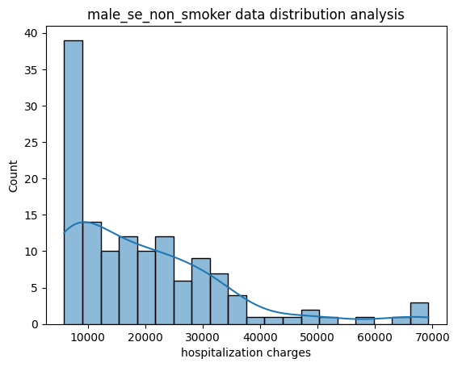

```
kurtosis for male_se_non_smoker:  2.4801054631069093
```

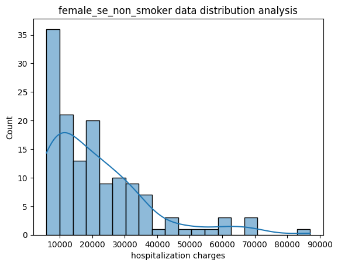

```
kurtosis for female_se_non_smoker:  3.0775203675525358
```

```python
plot_histogram(male_se_non_smoker,'male_se_non_smoker data distribution analysis',bins,kde=True)
print('kurtosis for male_se_non_smoker: ',kurtosis(male_se_non_smoker, bias=False))

plot_histogram(female_se_non_smoker,'female_se_non_smoker data distribution analysis',bins,kde=True)
print('kurtosis for female_se_non_smoker: ',kurtosis(female_se_non_smoker, bias=False))
```

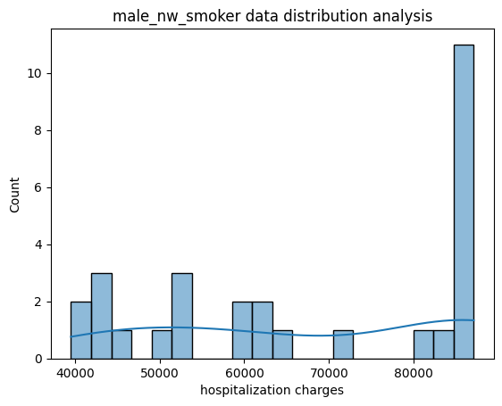

```
kurtosis for male_nw_smoker:  -1.7023322114279287
```

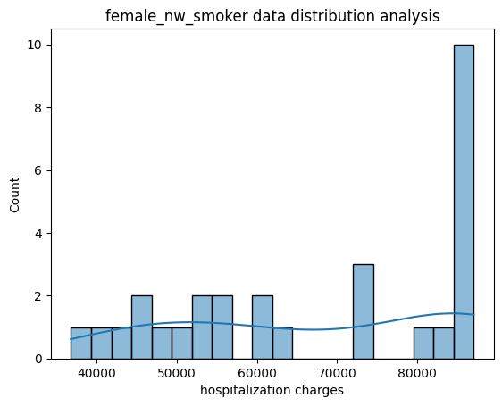

```
kurtosis for female_nw_smoker:  -1.5883326814141212
```

```python
plot_histogram(male_nw_smoker,'male_nw_smoker data distribution analysis',bins,kde=True)
print('kurtosis for male_nw_smoker: ',kurtosis(male_nw_smoker, bias=False))

plot_histogram(female_nw_smoker,'female_nw_smoker data distribution analysis',bins,kde=True)
print('kurtosis for female_nw_smoker: ',kurtosis(female_nw_smoker, bias=False))
```

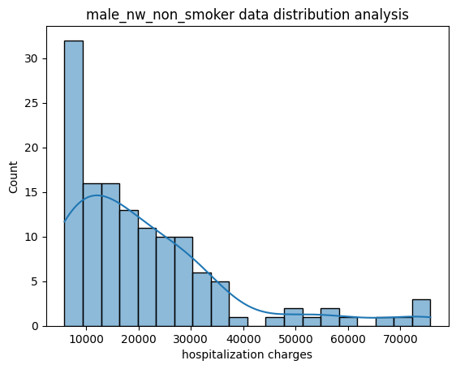

```
kurtosis for male_nw_non_smoker:  2.9531627027743212
```

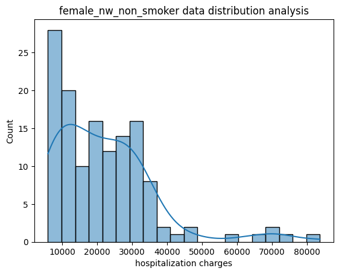

```
kurtosis for female_nw_non_smoker:  3.9431980474847563
```

```python
plot_histogram(male_nw_non_smoker,'male_nw_non_smoker data distribution analysis',bins,kde=True)
print('kurtosis for male_nw_non_smoker: ',kurtosis(male_nw_non_smoker, bias=False))

plot_histogram(female_nw_non_smoker,'female_nw_non_smoker data distribution analysis',bins,kde=True)
print('kurtosis for female_nw_non_smoker: ',kurtosis(female_nw_non_smoker, bias=False))
```

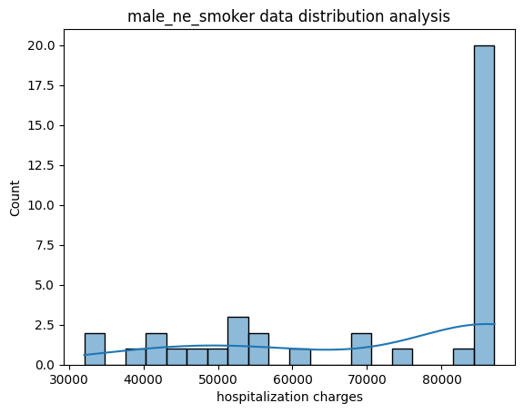

```
kurtosis for male_ne_smoker:  -1.198648657412898
```

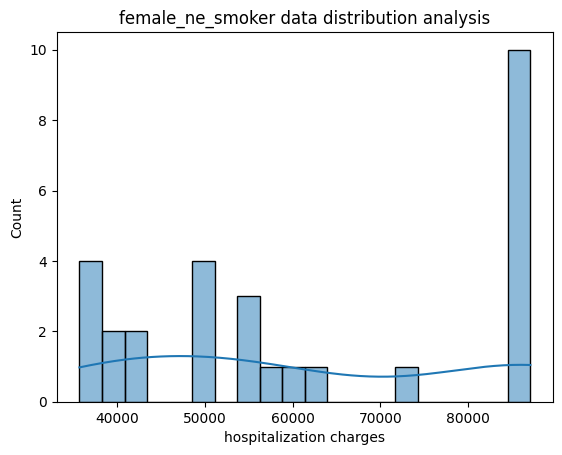

```
kurtosis for female_ne_smoker:  -1.6506419491482418
```

```python
plot_histogram(male_ne_smoker,'male_ne_smoker data distribution analysis',bins,kde=True)
print('kurtosis for male_ne_smoker: ',kurtosis(male_ne_smoker, bias=False))

plot_histogram(female_ne_smoker,'female_ne_smoker data distribution analysis',bins,kde=True)
print('kurtosis for female_ne_smoker: ',kurtosis(female_ne_smoker, bias=False))
```

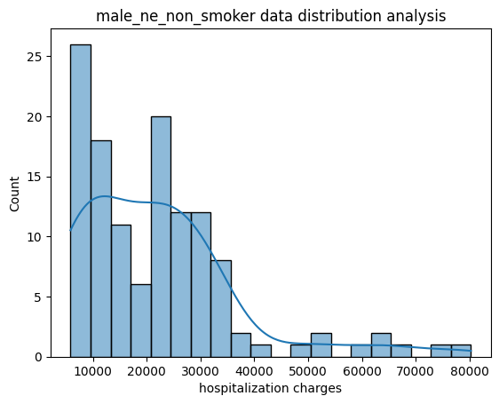

```
kurtosis for male_ne_non_smoker:  3.370318925339639
```

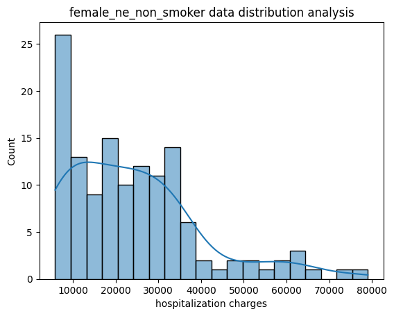

```
kurtosis for female_ne_non_smoker:  1.330568466092112
```

```python
plot_histogram(male_ne_non_smoker,'male_ne_non_smoker data distribution analysis',bins,kde=True)
print('kurtosis for male_ne_non_smoker: ',kurtosis(male_ne_non_smoker, bias=False))

plot_histogram(female_ne_non_smoker,'female_ne_non_smoker data distribution analysis',bins,kde=True)
print('kurtosis for female_ne_non_smoker: ',kurtosis(female_ne_non_smoker, bias=False))
```

# Levene test to check whether male and female smoker as well as non-smoker from different region have impact on hospitalization or not.

H0 : Male and female populations from different region who smoke as well as who not smoke have equal variance.

Ha : Male and female populations from different region who smoke as well as who not smoke have unequal variance.

alpha = 0.05

```python
alpha = 0.05
test_stats,p_value = levene(male_sw_smoker,male_sw_non_smoker,male_se_smoker,male_se_non_smoker,male_nw_smoker,male_nw_non_smoker,male_ne_smoker,male_ne_non_smoker,female_sw_smoker,female_sw_non_smoker,female_se_smoker,female_se_non_smoker,female_nw_smoker,female_nw_non_smoker,female_ne_smoker,female_ne_non_smoker,center='mean')
if(p_value <alpha):
    print("Reject the null hypothesis",p_value)
else:
    print("Fail to reject NULL hypothesis",p_value)
```

```
Reject the null hypothesis 5.461699145040578e-13
```

# Conclusion

# Is the mean viral load of women with 0 Severity level , 1 Severity level, and 2 Severity level the same?

```python
data.head()
```

|  | age | sex | smoker | region | viral load | severity level | hospitalization charges |
| --- | --- | --- | --- | --- | --- | --- | --- |
| 0 | 19 | female | yes | southwest | 9.30 | 0 | 42212.0 |
| 1 | 18 | male | no | southeast | 11.26 | 1 | 5866.1 |
| 2 | 28 | male | no | southeast | 11.00 | 3 | 11124.0 |
| 3 | 33 | male | no | northwest | 7.57 | 0 | 54961.0 |
| 4 | 32 | male | no | northwest | 9.63 | 0 | 9667.0 |

```python
data['severity level'].unique()
```

```
array([0, 1, 3, 2, 5, 4], dtype=int64)
```

```python
women_s0_viral_load = data.loc[(data['sex']=='female')&(data['severity level']==0)]['viral load']
women_s1_viral_load = data.loc[(data['sex']=='female')&(data['severity level']==1)]['viral load']
women_s2_viral_load = data.loc[(data['sex']=='female')&(data['severity level']==2)]['viral load']
women_s3_viral_load = data.loc[(data['sex']=='female')&(data['severity level']==3)]['viral load']
women_s4_viral_load = data.loc[(data['sex']=='female')&(data['severity level']==4)]['viral load']
women_s5_viral_load = data.loc[(data['sex']=='female')&(data['severity level']==5)]['viral load']
```

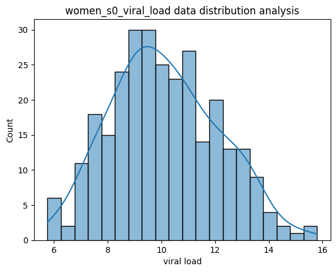

```
kurtosis for women_s0_viral_load:  -0.4101395073495784
```

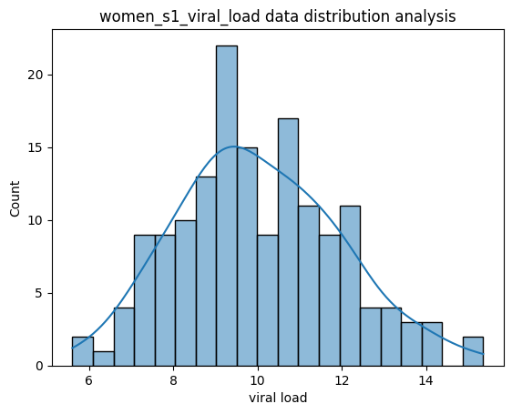

```
kurtosis for women_s1_viral_load:  -0.1623383987957845
```

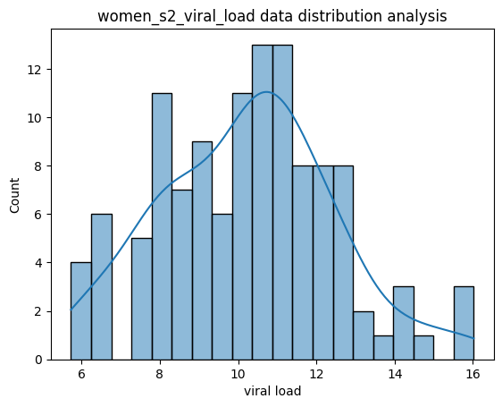

```
kurtosis for women_s2_viral_load:  -0.06989632006582225
```

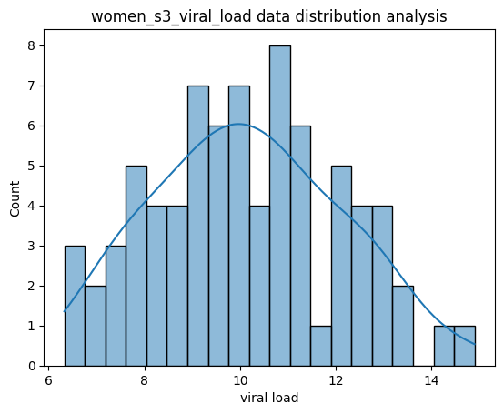

```
kurtosis for women_s3_viral_load:  -0.5397735612629444
```

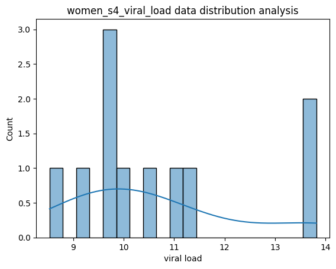

```
kurtosis for women_s4_viral_load:  0.3346228634637405
```

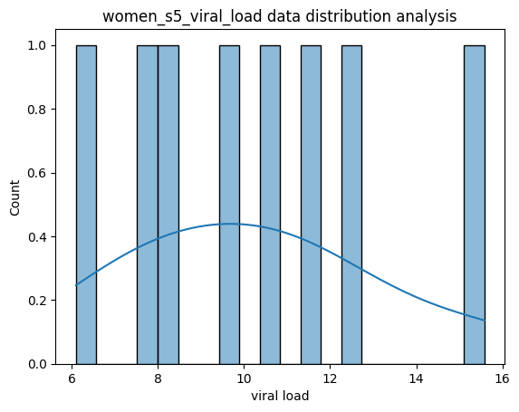

```
kurtosis for women_s5_viral_load:  0.29198237104893376
```

```python
plot_histogram(women_s0_viral_load,'women_s0_viral_load data distribution analysis',bins,kde=True)
print('kurtosis for women_s0_viral_load: ',kurtosis(women_s0_viral_load, bias=False))

plot_histogram(women_s1_viral_load,'women_s1_viral_load data distribution analysis',bins,kde=True)
print('kurtosis for women_s1_viral_load: ',kurtosis(women_s1_viral_load, bias=False))

plot_histogram(women_s2_viral_load,'women_s2_viral_load data distribution analysis',bins,kde=True)
print('kurtosis for women_s2_viral_load: ',kurtosis(women_s2_viral_load, bias=False))

plot_histogram(women_s3_viral_load,'women_s3_viral_load data distribution analysis',bins,kde=True)
print('kurtosis for women_s3_viral_load: ',kurtosis(women_s3_viral_load, bias=False))

plot_histogram(women_s4_viral_load,'women_s4_viral_load data distribution analysis',bins,kde=True)
print('kurtosis for women_s4_viral_load: ',kurtosis(women_s4_viral_load, bias=False))

plot_histogram(women_s5_viral_load,'women_s5_viral_load data distribution analysis',bins,kde=True)
print('kurtosis for women_s5_viral_load: ',kurtosis(women_s5_viral_load, bias=False))
```